# R Lecture 2 - tidyverse

# tidyverse

The tidyverse is a coherent system of packages for **data manipulation**, **exploration** and **visualization** that share a common design philosophy. Developed by R Studio scientist Hadley Wickham.

[Reference] https://rviews.rstudio.com/2017/06/08/what-is-the-tidyverse/

`install.packages("tidyverse")` `library(tidyverse)` will load the core tidyverse packages:

- *ggplot2*, for data visualisation.
- *dplyr*, for transforming and summarizing dataframe content.
- *tidyr*, for data tidying.
- *readr*, for data import.
- *purrr*, for functional programming.
- *tibble*, for tibbles, a modern re-imagining of data frames.

```r
### Install the packages ####
# install.packages("tidyverse") # Only do this one time

### Load the packages ###
library(tidyverse) # Do this for every R session where you use the package(s)
```

## `dplyr` Functions

http://tidyr.tidyverse.org/reference/index.html

https://betterdatascience.com/top-10-dplyr-functions%E2%80%8A-%E2%80%8Adata-analysis-made-easy/

Commands can be strung together in order using the pipe `%>%` operator.

| Function | Use |
| --- | --- |
| `filter()` | Filter data frame on row |
| `select()` | Filter data frame on column |
| `mutate()` | Add new column to data frame |
| `group_by()` | Establish a grouping for downstream operations. Remove with `ungroup()` |
| `tally()` | Count the number of observations per grouping |
| `summarize()` | Perform a summary statistic on a column. Also can spell `summarise()` |
| `arrange()` | Arrange a column |

*before we learned…*

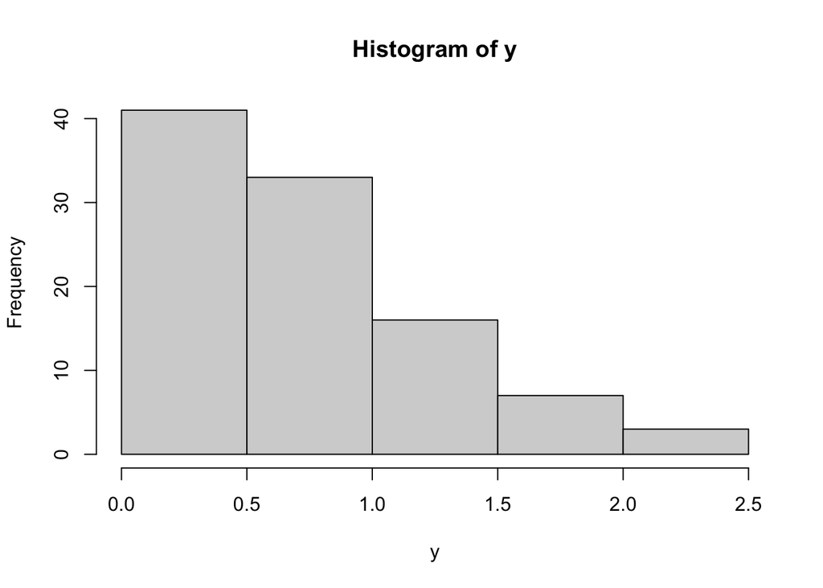

```r
set.seed(1)
x = rnorm(100)
y = abs(x)
hist(y)
```

*now, with `%>%`*

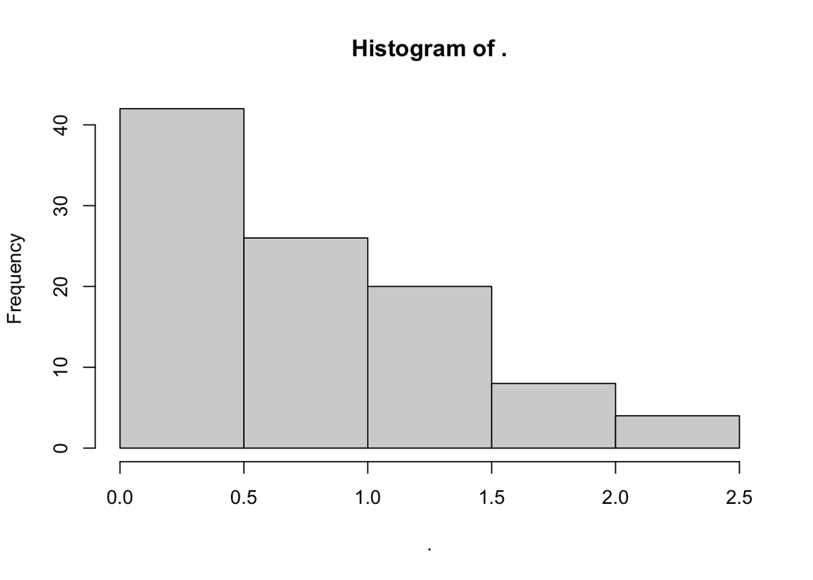

```r
rnorm(100) %>%
  abs() %>%
  hist()
```

# Car sale example

```r
load("carsale.Rda")
```

```r
mydata %>%
  dim()
```

```r
mydata %>%
  summary()
mydata %>%
  str()
mydata %>%
  filter(maker=="toyota") #subset
```

```r
mydata %>%
  filter(price >= 15000 & maker =="toyota") #subset

mydata %>%
  select(maker, year) #show maker and year

mydata %>%
  select(type, price, everything()) %>% #change the order of variables
  head()

mydata %>%
  filter(maker =="toyota") %>%
  select(year)

mydata %>%
  summarise(mean(price, na.rm = TRUE)) #mean

mydata %>%
  group_by(maker) %>%
  summarise(mean(price, na.rm = TRUE))

mydata %>%
  mutate(new_price = price*0.5) #create a new variable

mydata %>%
  arrange(price) #sort in ascending order. in descending order: arrange(desc(price))

mydata %>%
  filter(price >= 15000 & maker =="toyota") %>%
  tally()  #how many

mydata %>%
  sample_frac(0.002) #sampling by proportion

mydata %>%
  sample_n(5) #sampling by size
```

### Exercise 1

Dataset `data(flights)` contains all 336,776 flights that departed from New York City in 2013. The data comes from the US Bureau of Transportation Statistics, and is documented in ?flights.

```r
install.packages("nycflights13")
library(nycflights13)
```

1. filter出 dest為LAX, SFO, ORD 和 LGB，留下這些變數year, month, day, arr_delay, origin, dest, dep_time。將row根據year, month, day, arr_delay重新排序
2. 計算每個dest出現次數。計算每個origin, dest組合出現次數
3. 新增一個變數 speed = distance / air_time * 60，並將year變數改名為YEAR。存成另一個檔flights2
4. 算每個月的平均speed，並計算每個月有幾筆資料

## `tidyr`

What is a dataset?

- A collection of *values*
- Each *value* belongs to a variable and an *observation*
- *Variables* contain all values that measure the same  
  underlying attribute (“thing”)
- *Observations* contain all values measured on the same unit across attributes.

A tidy data set needs:

- each row is a unit of observation
- each column is a single piece of information
- each cell is a value

`gather()`, `spread()`, `separate()`, `unite()`

| function | use |
| --- | --- |
| gather() | Gather multiple columns into key:value pairs |
| spread() | Spread key:value pairs over multiple columns |
| separate() | Separate columns |
| unite() | Join columns |

Inside pkg `tidyr`: `table1` is tidy: Each column is a variable and each row is an observation.

```r
table1
```

| country | year | cases | population |
| --- | --- | --- | --- |
| Afghanistan | 1999 | 745 | 19987071 |
| Afghanistan | 2000 | 2666 | 20595360 |
| Brazil | 1999 | 37737 | 172006362 |
| Brazil | 2000 | 80488 | 174504898 |
| China | 1999 | 212258 | 1272915272 |
| China | 2000 | 213766 | 1280428583 |

### spread函數把多個變數儲存在同一個 column 中 分開

`table2` is not tidy because observations are spread across multiple rows. This calls for the verb spread().

原本把 variables 當成 value 存在同一個 column的情況，這裡把 cases 與 population 兩個變數存在同一個 column。spread 其實就是 gather 的相反，也就是多個變數儲存在同一個 column 中

- 指令的敘述如下：

```r
spread(data,
       key,
       value,
       fill = NA,
       convert = FALSE,
       drop = TRUE,
       sep = NULL)
```

其中比較重要的參數有：

- key：要被拆開成 variables 的 column
- sep：如果是 NULL，回直接將 key 的值當成新 columns 的名稱，如果輸入其他分隔符號，會回傳：“paste0(key_name,sep,key_value)”。

```r
table2
```

```r
table2 %>% spread(type, count)
```

```r
table2 %>%
  spread(key = type,
         value = count,
         sep = '_')
```

### 多個變數儲存在同一個 column 中 - 使用 separate函數

`table3` is not tidy because there are two variables contained in the column rate. This calls for the verb separate().

```r
separate(data,
         col,
         into,
         sep = "",
         remove = TRUE,
         convert = FALSE,
         extra = "warn",
         fill = "warn",
         ...)
```

裡面比較重要的參數有：

- col：需要被分開column的名稱
- into：分隔成新columns的名稱
- sep：用來分隔欄位的分隔符號，以正規表達式 (regular expression) 表示。

```r
table3 %>% separate(rate, into=c("cases", "population"), sep = "/")

table3 %>% separate(rate, into=c("cases", "population"), sep = "/", convert = TRUE)
```

### Column 其實是值而不是變數 - 使用 gather函數

`table4a` and `table4b` together contain all information in `table1`. Each of these is not tidy because it misuses values as variables, which calls for the verb `gather()`. Further, to recreate table1, we must use the dplyr function `left_join()`.

```r
gather(data,
       key = "key",
       value = "value",
       ...,
       na.rm = FALSE,
       convert = FALSE,
       factor_key = FALSE)
```

其中最重要的函數輸入有四個部分：

- data：待處理的資料
- key：新變數的欄位名稱
- value：新變數變數值的儲存欄位名稱
- …：要被蒐集起來變成新變數的 columns

```r
tidy4a <- table4a %>% gather(year, cases, `1999`:`2000`)
tidy4a
(tidy4b <- table4b %>% gather(year, population, `1999`:`2000`) )

left_join(tidy4a, tidy4b)
```

### 一個變數被分存在不同 columns 中 - 使用 unite 函數

有時候我們也會遇到把同一個變數儲存在不同 columns 的情況，如：日期被分開成年、月、日，反而造成建模或繪圖的困擾。 這時我們可以使用 unite 函數合併兩個 columns，指令如下：

```r
unite(data,
      col,
      ...,
      sep = "_",
      remove = TRUE)
```

其中比較重要的參數有：

- col：合併完成後的新 column 名稱
- …：用來合併的原有 columns 名稱
- sep：用來分隔欄位的分隔符號，以正規表達式 (regular expression) 表示。

```r
table5 %>% unite(Year, century, year, sep="") %>%
    separate(rate, into=c("cases", "population"), sep = "/", convert=TRUE)
```

### Exercise 2

creat a data set:

```r
df = tibble(sub = c(1,2,3), treat = c("A","B","C"),
            t_1 = c(0.1,0.2,0.3), t_2 = c(4,5,6),
            t_3 = c(7,8,9), t_4 = c(1,1,1), t_5 = c(1.3,2.3,3.3)
            )
```

then covert the data into different styles 1~5:

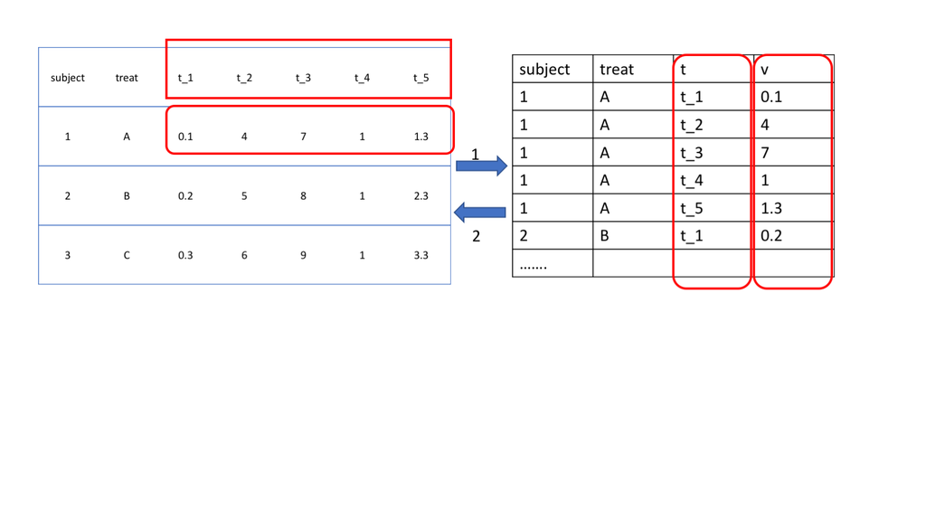

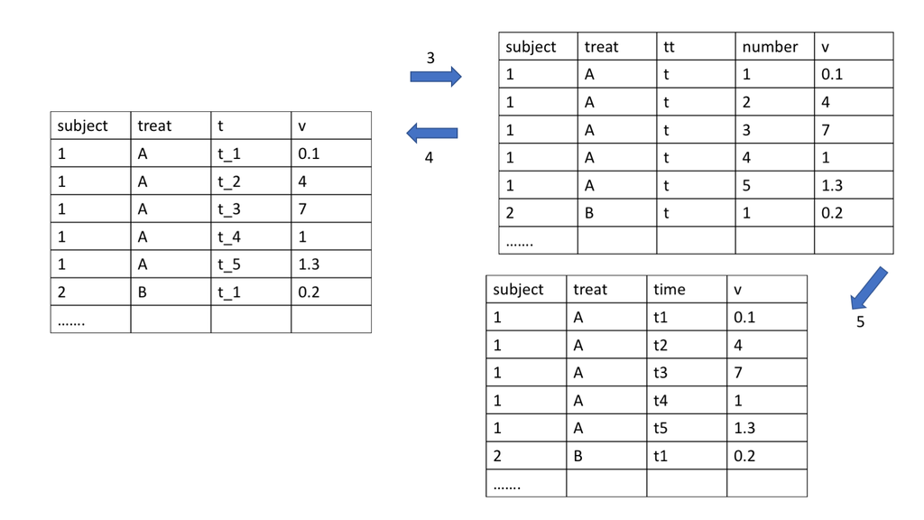

# 合併資料

當我們要串連多個資料表時，可利用「鍵」(key) 來串連不同的資料表，一般來說有兩種重要的連結鍵：

- 主鍵 (Primary Key)：用來辨識 row 的欄位, 一個 row 只能有一個 primary key value，而且 primary key values 不能重複。
- 連外鍵 (Foreign Key)：用來連結其他資料表主鍵之用的連結鍵。 通常我們會喜歡用編號 / ID 來作為主鍵。在連結時，常將兩個資料表的主鍵做連結，或是一個資料表的主鍵與另一資料表的連外鍵。

Import data:

```r
library(readr)
student <- read_csv("lec2_data1.csv")
moodle <- read_csv("lec2_data2.csv")
course <- read_csv("lec2_data3.csv")
```

上述三個資料集合，其實是透過下列方式相互連結的：

- student：主鍵為 id，連外鍵為 moodle_id 與 lecture_id
- moodle：主鍵為 moodle_id，無連外鍵
- course：主鍵為 lecture_id，無連外鍵

## `inner_join`

#### 語法

```
table.A %>% inner_join(table.B)
```

比對 table.A 中 rows 的key值是否出現在 table.B 的key值中

如果該 row 的key值有出現在 table.B 的key值中，則根據相同的 row 與 table.B 合併，不在的就不會一起合併

## 例子

合併student and moodle by key: moodle_id

```r
library(tidyverse)
student %>% inner_join(moodle)
```

| id | gender | age | city | lecture_id | moodle_id | time |
| --- | --- | --- | --- | --- | --- | --- |
| 1 | male | 19 | Taipei | L1 | 7 | 5 |
| 2 | female | 20 | Tainan | L2 | 6 | 4 |
| 3 | male | 22 | Taipei | L3 | 1 | 30 |
| 4 | female | 24 | Taipei | L1 | 2 | 20 |
| 5 | female | 22 | Tainan | L2 | 3 | 40 |
| 6 | female | 21 | Taipei | L3 | 5 | 10 |
| 7 | male | 20 | Tainan | L2 | 4 | 30 |

## `full_join`

#### 語法

```
table.A %>% full_join(table.B)
```

比對 table.A 中 rows 的key值是否出現在 table.B 的key值中

如果該 row 的key值有出現在 table.B 的key值中，則根據相同的 row 與 table.B 合併，不在的也會一起合併

```r
moodle2 <- moodle[c(1:3),]
student %>% full_join(moodle2)
```

| id | gender | age | city | lecture_id | moodle_id | time |
| --- | --- | --- | --- | --- | --- | --- |
| 1 | male | 19 | Taipei | L1 | 7 | NA |
| 2 | female | 20 | Tainan | L2 | 6 | NA |
| 3 | male | 22 | Taipei | L3 | 1 | 30 |
| 4 | female | 24 | Taipei | L1 | 2 | 20 |
| 5 | female | 22 | Tainan | L2 | 3 | 40 |
| 6 | female | 21 | Taipei | L3 | 5 | NA |
| 7 | male | 20 | Tainan | L2 | 4 | NA |

## `left_join`, `right_join`

Left join 會將 A 集合中的所有個體與 B 集合的變數合併

Right join 會將 A 集合中的所有出現在 B 集合的個體其變數與 B 集合的變數合併

#### 語法

```
table.A %>% left_join(table.B)
table.A %>% right_join(table.B)
```

```r
student2 <- moodle[-6,]
student2 %>% left_join(moodle2)
```

| moodle_id | time |
| --- | --- |
| 1 | 30 |
| 2 | 20 |
| 3 | 40 |
| 4 | 30 |
| 5 | 10 |
| 7 | 5 |

```r
student2 %>% right_join(moodle2)
```

| moodle_id | time |
| --- | --- |
| 1 | 30 |
| 2 | 20 |
| 3 | 40 |

```r
full<- student %>%
  left_join(moodle, by = "moodle_id") %>%  #如果有很多key，可指定 (by)
  left_join(course)
full
```

| id | gender | age | city | lecture_id | moodle_id | time | course |
| --- | --- | --- | --- | --- | --- | --- | --- |
| 1 | male | 19 | Taipei | L1 | 7 | 5 | Statistics |
| 2 | female | 20 | Tainan | L2 | 6 | 4 | R |
| 3 | male | 22 | Taipei | L3 | 1 | 30 | Seminar |
| 4 | female | 24 | Taipei | L1 | 2 | 20 | Statistics |
| 5 | female | 22 | Tainan | L2 | 3 | 40 | R |
| 6 | female | 21 | Taipei | L3 | 5 | 10 | Seminar |
| 7 | male | 20 | Tainan | L2 | 4 | 30 | R |